# College Rankings and State Characteristics[^1]

Author

Felix Omondi

Published

October 8, 2023

# Packages loading

```r
library(tidyverse)
library(colorblindr)
library(dplyr)
```

### Loading data

```r
# load data here using appropriate readr and readxl functions
presvote_pop <- read_csv("presvote_pop.csv", show_col_types = FALSE)
colleges <- readxl::read_excel("colleges.xlsx")
universities <- readxl::read_excel("universities.xlsx")
```

## Data Wrangling

### tidying the colleges dataset

```r
colleges <- pivot_longer(colleges,
                         cols = c("2023", "2022", "2021", "2020", "2019",
                                  "2018","2017", "2016", "2015", "2014",
                                  "2013", "2012", "2011", "2010", "2009"),
                         names_to = "year",
                         values_to = "ranking")
colleges
```

```
# A tibble: 1,515 × 4
   school           state year  ranking
   <chr>            <chr> <chr>   <dbl>
 1 Williams College MA    2023        1
 2 Williams College MA    2022        1
 3 Williams College MA    2021        1
 4 Williams College MA    2020        1
 5 Williams College MA    2019        1
 6 Williams College MA    2018        1
 7 Williams College MA    2017        1
 8 Williams College MA    2016        1
 9 Williams College MA    2015        1
10 Williams College MA    2014        1
# ℹ 1,505 more rows
```

### tidying the universities dataset

```r
universities <- pivot_longer(universities,
                         cols = c("2023", "2022", "2021", "2020", "2019",
                                  "2018","2017", "2016", "2015", "2014",
                                  "2013", "2012", "2011", "2010", "2009"),
                         names_to = "year",
                         values_to = "ranking")
universities
```

```
# A tibble: 1,560 × 4
   school               state year  ranking
   <chr>                <chr> <chr>   <dbl>
 1 Princeton University NJ    2023        1
 2 Princeton University NJ    2022        1
 3 Princeton University NJ    2021        1
 4 Princeton University NJ    2020        1
 5 Princeton University NJ    2019        1
 6 Princeton University NJ    2018        1
 7 Princeton University NJ    2017        1
 8 Princeton University NJ    2016        1
 9 Princeton University NJ    2015        1
10 Princeton University NJ    2014        1
# ℹ 1,550 more rows
```

```r
colleges <- colleges |>
  mutate(type = "college")

universities <- universities |>
  mutate(type = "universities")
```

#### combining the two data sets using by the type columns created above

```r
full_data <- bind_rows(colleges, universities)
full_data
```

```
# A tibble: 3,075 × 5
   school           state year  ranking type
   <chr>            <chr> <chr>   <dbl> <chr>
 1 Williams College MA    2023        1 college
 2 Williams College MA    2022        1 college
 3 Williams College MA    2021        1 college
 4 Williams College MA    2020        1 college
 5 Williams College MA    2019        1 college
 6 Williams College MA    2018        1 college
 7 Williams College MA    2017        1 college
 8 Williams College MA    2016        1 college
 9 Williams College MA    2015        1 college
10 Williams College MA    2014        1 college
# ℹ 3,065 more rows
```

## Data Analysis

### Top 5 states with the largest number of schools in the top 100

```r
full_data |>
  filter(year == "2023") |>
  count(state, sort = TRUE) |>
  slice(1:5)
```

```
# A tibble: 5 × 2
  state     n
  <chr> <int>
1 CA       24
2 NY       22
3 PA       19
4 MA       18
5 IL        9
```

- The states with the five largest number of schools include: CA, NY, PA, MA, and IL

```r
presvote_pop <- presvote_pop |>
  rename(state = abbrev)
```

### joining the data set containing schools with the elections an population dataset

```r
full_data |>
  right_join(presvote_pop,
             by = "state",
             relationship = "many-to-one") |>
  rename(population = `2020pop`) |>
  filter(is.na(school)) |>
  arrange(desc(population)) |>
  select("state","population")
```

```
# A tibble: 15 × 2
   state population
   <chr>      <dbl>
 1 AZ       7151502
 2 OK       3959353
 3 NV       3104614
 4 AR       3011524
 5 MS       2961279
 6 KS       2937880
 7 NE       1961504
 8 ID       1839106
 9 WV       1793716
10 HI       1455271
11 MT       1084225
12 SD        886667
13 ND        779094
14 AK        733391
15 WY        576851
```

- 15 states do not have a school in full_data.
- The state with the largest population and does not have a school in full_data is AZ

### A plot to show the rankings of specific colleges

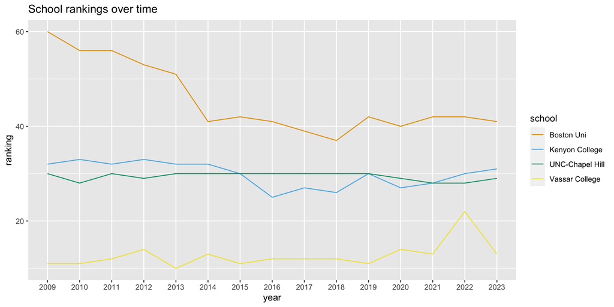

A line plot to show the rankings of Vassar College, Kenyon College , Boston University, and University of North Carolina-Chapel Hill over time

```r
full_data |>
  filter(school %in% c("Vassar College", "Kenyon College", "Boston University",
         "University of North Carolina-Chapel Hill")) |>
  ggplot(mapping = aes(x = year, y = ranking, group = school, color = school)) +
  geom_line() +
  labs(title = "School rankings over time") +
  scale_color_OkabeIto(labels = c("Boston Uni", "Kenyon College",
                                  "UNC-Chapel Hill", "Vassar College"))
```

- The plot shows that Vassar College has been ranked the highest among the four schools over time. Boston University’s ranking has been increasing over time , while University of North Carolina-Chapel Hill has received almost steady rankings over time.University of North Carolina and Kenyon College received the same rankings in 2015.

### A plot to show the relationship between population of a state and the number of schools

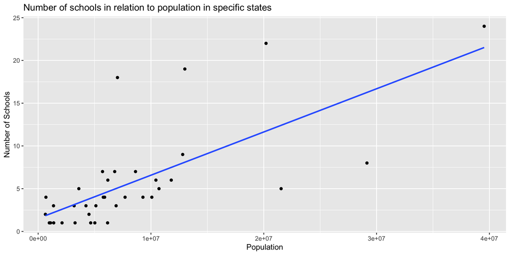

A scatterplot and a line of best fit of the number of schools per state compared to the population of that state

```r
full_data |>
  filter(year == 2023) |>
  count(state) |>
  left_join(presvote_pop, by = "state", relationship = "many-to-one") |>
  ggplot(mapping = aes(x = `2020pop`, y = n)) +
  geom_point() +
  geom_smooth(method = "lm", se = FALSE) +
  labs(
    title = "Number of schools in relation to population in specific states",
    x = "Population",
    y = "Number of Schools") +
  scale_color_OkabeIto()
```

- There is a positive relation between the number of schools in a state and the population of the given state. The more the population, the higher the number of schools in the state.
- yes, this is what I would expect because the more the population the more the number of schools required to sustain the population in a given area.
- Yes, most points fall near the line of best fit.

### Showing the results of the previous elections per state in relation to the number of schools and population

```r
counts <- full_data |>
  filter(year == 2023) |>
  count(type, state) |>
  pivot_wider(names_from = type,
              values_from = n,
              values_fill = 0) |>
  left_join(presvote_pop, by = "state", relationship = "many-to-one") |>
  mutate(biden_pct = (bidenvotes / (bidenvotes + trumpvotes))) |>
  mutate(winner = if_else(biden_pct > 0.5, "Biden", "Trump"))
counts
```

```
# A tibble: 36 × 8
   state college universities trumpvotes bidenvotes `2020pop` biden_pct winner
   <chr>   <int>        <int>      <dbl>      <dbl>     <dbl>     <dbl> <chr>
 1 CA          8           16    6006429   11110250  39538223     0.649 Biden
 2 CO          2            2    1364607    1804352   5773714     0.569 Biden
 3 CT          3            2     714717    1080831   3605944     0.602 Biden
 4 FL          1            4    5668731    5297045  21538187     0.483 Trump
 5 GA          2            3    2461854    2473633  10711908     0.501 Biden
 6 IA          2            1     897672     759061   3190369     0.458 Trump
 7 IL          5            4    2446891    3471915  12812508     0.587 Biden
 8 IN          4            3    1729519    1242416   6785528     0.418 Trump
 9 KY          2            0    1326646     772474   4505836     0.368 Trump
10 MA          8           10     976414    1985023   7029917     0.670 Biden
# ℹ 26 more rows
```

### Showing the distribution of wins per state. Shows who won in which specific state in the past election

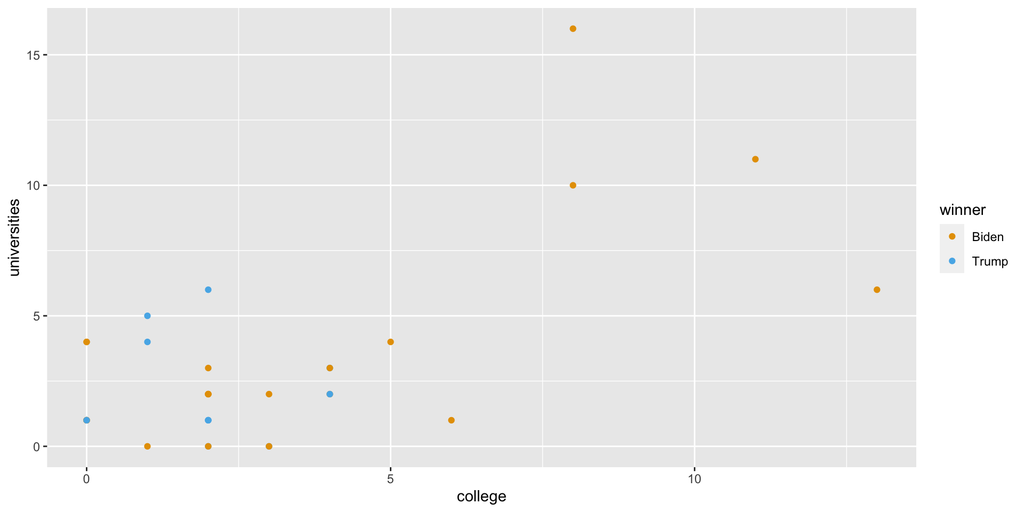

A scatterplot of the number of collges and universities in a state. colored by who won the elections in that state.

```r
counts |>
  ggplot(mapping = aes(x = college, y = universities, color = winner)) +
  geom_point() +
  scale_color_OkabeIto()
```

- Biden won in many states. Ho mostly also won the states with the highest number of colleges, meaning that he won in the states that had the highest number of population as we have seen previously.

## Footnotes

[^1]: Adapted from Duke University’s STA 199 Lab